# lab2

Yuchen Song_201830360498-Xuewen Wang_201830120252

2021/9/15

## Load data

```r
load(url("http://www.stat.duke.edu/~cr173/Sta102_Sp16/Lab/cdc.Rdata"))
```

### Ex1

```r
dim(cdc)
```

```
## [1] 20000     9
```

There are 20,000 cases in this data set, and 9 variables.  
genhlth: categorical(excellent, very good, good, fair or poor)  
exerany: categorical(1,0)  
hlthplan: categorical(1,0) smoke100: categorical(1,0)  
height: quantitative  
weight: quantitative  
wtdesire: quantitative  
age: quantitative  
gender: categorical(m,f)

### Ex2

Numerical summary:

```r
summary(cdc$height)
```

```
##    Min. 1st Qu.  Median    Mean 3rd Qu.    Max.
##   48.00   64.00   67.00   67.18   70.00   93.00
```

```r
summary(cdc$age)
```

```
##    Min. 1st Qu.  Median    Mean 3rd Qu.    Max.
##   18.00   31.00   43.00   45.07   57.00   99.00
```

Interquartile range:

```r
IQR(cdc$height)
```

```
## [1] 6
```

```r
IQR(cdc$age)
```

```
## [1] 26
```

Relative frequency distribution:

```r
table(cdc$gender)/20000
```

```
##
##       m       f
## 0.47845 0.52155
```

```r
table(cdc$exerany)/20000
```

```
##
##      0      1
## 0.2543 0.7457
```

Males in the sample:

```r
table(cdc$gender)["m"]
```

```
##    m
## 9569
```

Proportion of the excellent health:

```r
table(cdc$genhlth)["excellent"]/20000
```

```
## excellent
##   0.23285
```

### Ex3

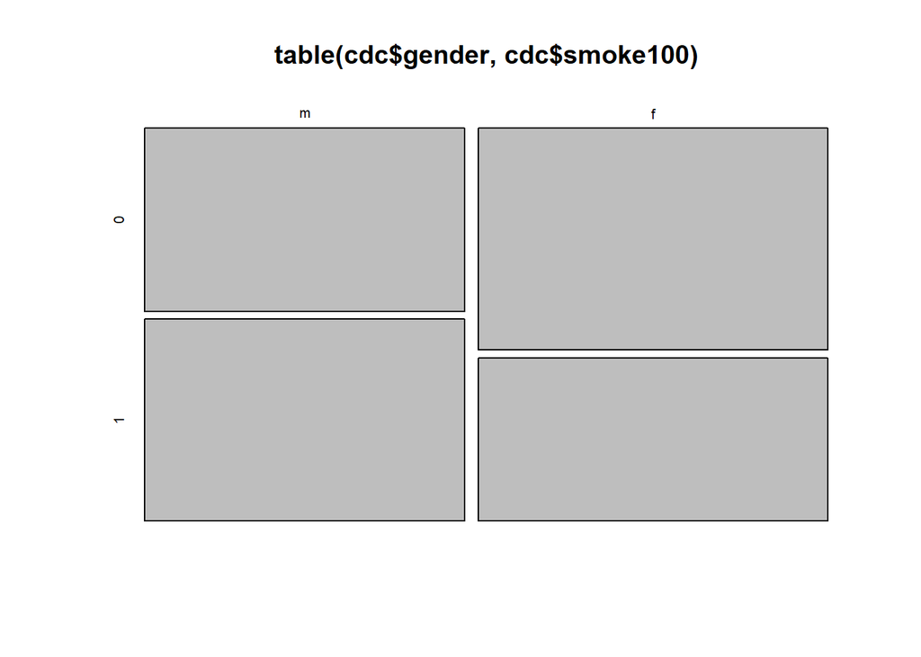

```r
mosaicplot(table(cdc$gender,cdc$smoke100))
```

The mosaic plot reveals that males are more prone to smoke over 100 cigarettes in the lifetime.

### Ex4

```r
under23_and_smoke <- subset(cdc, cdc$age<23 & cdc$smoke100==1)
```

### Ex5

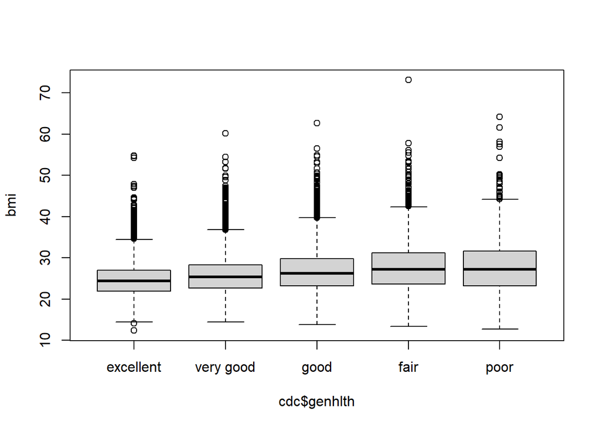

The box plot shows that with the general health condition improves, the less BMI is likely to get and the denser the distribution will be.

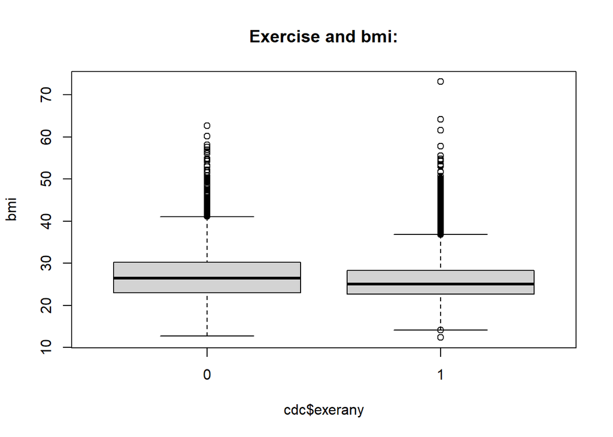

We think that exercise makes people healthier, so it must has something to do with the bmi.  
The figure suggests that the people who exercised in the past month are more likely to have lower bmi, but the spread shows that there may be someone who want to just started excerse so their bmi didn’t improve sharply.

### Ex6

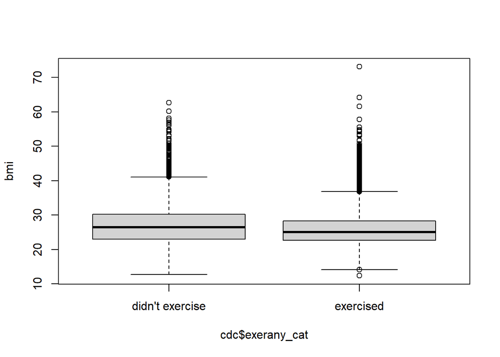

```r
cdc$exerany_cat = NA  # create new variable, and fill it in with NAs first
cdc$exerany_cat[cdc$exerany == 1] = "exercised"
cdc$exerany_cat[cdc$exerany == 0] = "didn't exercise"
cdc$exerany_cat = as.factor(cdc$exerany_cat)  # save new variable as factor
boxplot(bmi ~ cdc$exerany_cat)
```

### Ex7

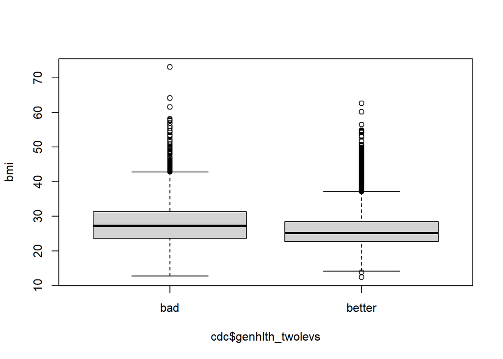

```r
cdc$genhlth_twolevs = NA  # create new variable, and fill it in with NAs first
cdc$genhlth_twolevs[cdc$genhlth %in% c("fair", "poor")] = "bad"
cdc$genhlth_twolevs[cdc$genhlth %in% c("good", "very good", "excellent")] = "better"
cdc$genhlth_twolevs = as.factor(cdc$genhlth_twolevs)  # save new variable as factor
boxplot(bmi ~ cdc$genhlth_twolevs)
```

### Ex8

```r
median_height = median(cdc$height)
cdc$height_cat = NA  # create new variable, and fill it in with NAs first
cdc$height_cat[cdc$height < median_height] = "below median"
cdc$height_cat[cdc$height >= median_height] = "at or above median"
cdc$height_cat = as.factor(cdc$height_cat)  # save new variable as factor
cdc$height_cat = factor(cdc$height_cat, levels = c("below median", "at or above median"))
table(cdc$height_cat)
```

```
##
##       below median at or above median
##               9200              10800
```

### Ex9

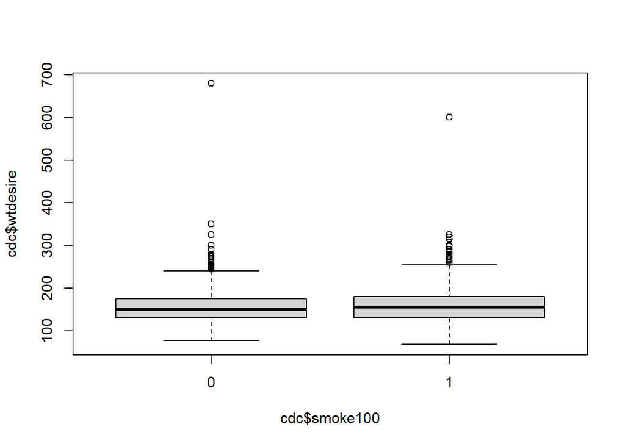

```r
boxplot(cdc$wtdesire ~ cdc$smoke100)
```

From the box plot, we cannot say there is an apparent relationship between the two viables, so we draw another plot, namely, mosaic plot.

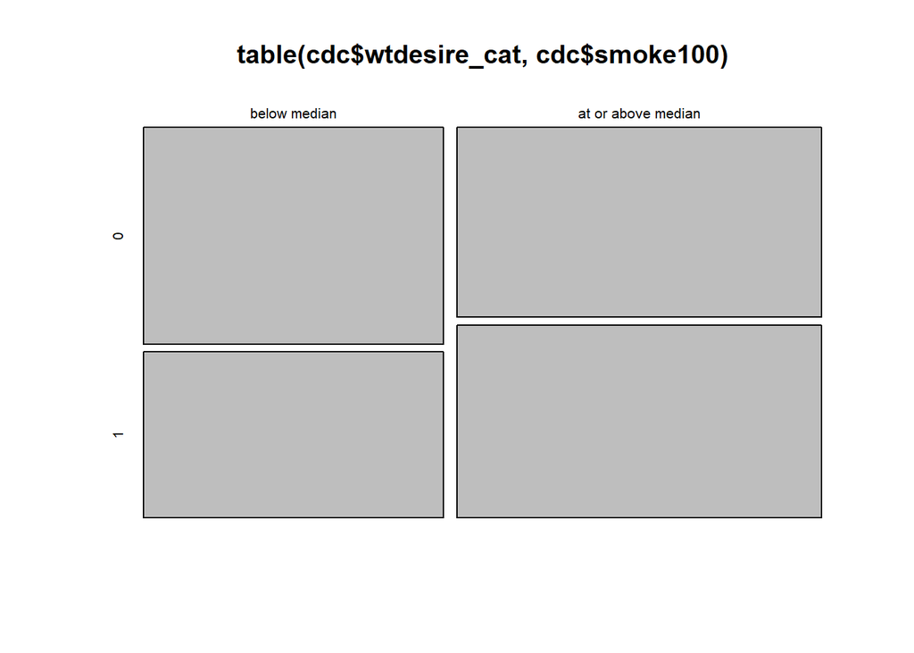

```r
median_wtdesire = median(cdc$wtdesire)
cdc$wtdesire_cat = NA  # create new variable, and fill it in with NAs first
cdc$wtdesire_cat[cdc$wtdesire < median_wtdesire] = "below median"
cdc$wtdesire_cat[cdc$wtdesire >= median_wtdesire] = "at or above median"
cdc$wtdesire_cat = as.factor(cdc$wtdesire_cat)  # save new variable as factor
cdc$wtdesire_cat = factor(cdc$wtdesire_cat, levels = c("below median", "at or above median"))
mosaicplot(table(cdc$wtdesire_cat,cdc$smoke100))
```

We separate the data into two categories, one below median and the other above median.  
From the mosaic plot we can see that as the desired weight grows, the number of cigarettes consumed over 100 increases.

### Ex10

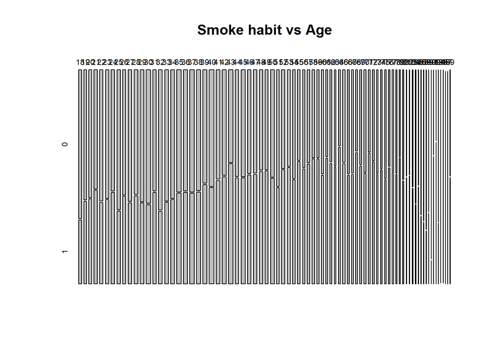

```r
mosaicplot(table(cdc$age,cdc$smoke100),main = "Smoke habit vs Age")
```

Before ~65, the number of people who smoke over 100 cigarettes increases, and after that the number drops. We assume that people who lives longer lives don’t smoke that much.

### Ex11

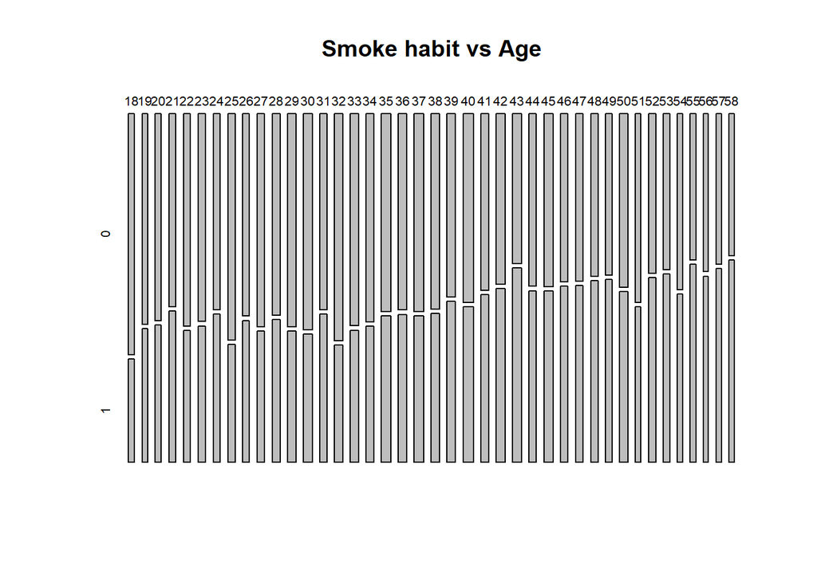

```r
mosaicplot(table(cdc$age[cdc$age>=18 & cdc$age<=58],cdc$smoke100[cdc$age>=18 & cdc$age<=58]),main = "Smoke habit vs Age")
```